[OHI-Northeast](http://www.ohi-northeast.org/) | [OHI Science](http://ohi-science.org) | [Citation policy](http://ohi-science.org/citation-policy/)

# Trash data layer

Compiled on Fri May 15 17:25:28 2020 by afflerbach

## Summary

The trash layer is derived from [Ocean Conservancy data](https://oceanconservancy.org/trash-free-seas/international-coastal-cleanup/annual-data-release/)) on the pounds of trash collected on International Coastal Cleanup Day.

```r
knitr::opts_chunk$set(fig.width = 10, fig.height = 6, fig.path = 'figs/', message = FALSE, warning = FALSE)

source('~/github/ne-prep/src/R/common.R')

library(tidyverse)
```

## Data Wrangling

This data was manually copied and pasted from the [Ocean Conservancy website](https://oceanconservancy.org/trash-free-seas/international-coastal-cleanup/annual-data-release/) as it is not provided in an easy to use format. The “raw” data is an excel file with one sheet for each year. There are also some weird issues like a mix of lower and uppercase letters for the states.

The data is filtered to only those states in our regions (NY to Maine) as well as the Mid-Atlantic states for setting a reference point later on. I add in a column, `pounds_per_person` which calculates the total pounds per volunteer.

```r
clean_func <- function(year) {

raw <- readxl::read_excel(file.path(dir_anx, "_raw_data/OceanConservancy/CoastalCleanup_Data.xlsx"), sheet = year) %>%
  mutate(year = as.numeric(year),
         state = tolower(.[[1]]),
         people = .[[2]],
         pounds = as.numeric(.[[3]])) %>% #for some reason one of the sheets was having pounds read in as character. forcing it to numeric here
  mutate(state_fix =
           case_when(
             state == "new ampshire" ~ "new hampshire",
             state == "new  hampshire" ~ "new hampshire",
             state == "new  jersey" ~ "new jersey",
             state == "new ork" ~ "new york",
             state == "new  york" ~ "new york",
             state == "rhode  island" ~ "rhode island"
           ))  %>%
  mutate(State = ifelse(is.na(state_fix), state, state_fix)) %>%
  select(year, state = State, people, pounds) %>%
  filter(state %in% c("new york", "connecticut", "maine", "massachusetts", "rhode island", "new jersey", "new hampshire", "maryland", "virginia", "delaware")) %>%
  mutate(pounds_per_person = pounds/people)

return(raw)
}

years <- as.character(c(2005:2017)) #need to be characters to use years as sheet names in read_excel

out <- map_df(years, clean_func)

#add up all states to get a sense of pounds/person for whole northeast
ne_states <- out %>%
  filter(state %in% c("maine", "new hampshire", "massachusetts", "new york", "connecticut", "rhode island"))

all_ne <- ne_states %>%
  group_by(year) %>%
  summarize(people = sum(people),
            pounds = sum(pounds)) %>%
  ungroup() %>%
  mutate(pounds_per_person = pounds/people,
         state = "Northeast")

ne_data <- bind_rows(ne_states, all_ne)
```

## Visualize data

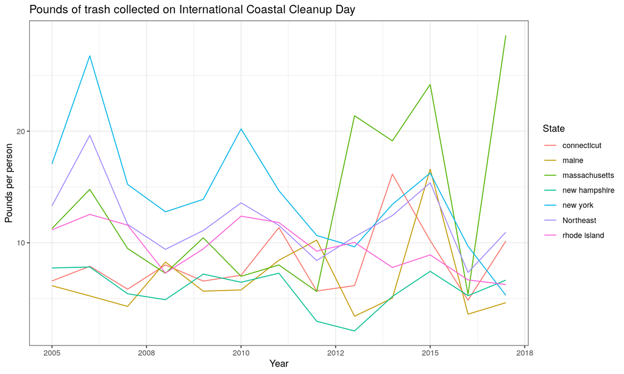

```r
ggplot(ne_data, aes(x = year, y = pounds_per_person, color = state)) +
  geom_line() +
  theme_bw() +
  labs(x = "Year",
       y = "Pounds per person",
       title = "Pounds of trash collected on International Coastal Cleanup Day",
       color = "State")
```

## Reference point

We need to decide how much trash per person would get a score of 0 and 100. The goal is 0 pounds per person so that is easy to set for a target. Since deciding how much trash is too much is a very subjective question, we can use the data to select a reference point. We are going to look across the Northeast and Mid-Atlantic region, find the highest level across the entire time series and then multiply that value by 10%.

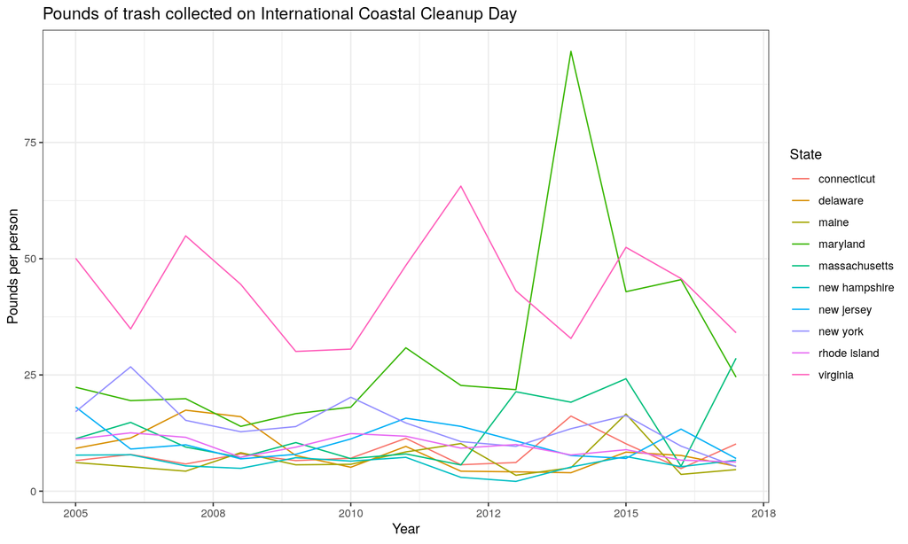

```r
ggplot(out, aes(x = year, y = pounds_per_person, color = state)) +
  geom_line() +
  theme_bw() +
  labs(x = "Year",
       y = "Pounds per person",
       title = "Pounds of trash collected on International Coastal Cleanup Day",
       color = "State")
```

It looks like Maryland has the highest amount.

```r
out %>%
  filter(pounds_per_person > 75)
```

```
## # A tibble: 1 x 5
##    year state    people pounds pounds_per_person
##   <dbl> <chr>     <dbl>  <dbl>             <dbl>
## 1  2014 maryland   1470 139063              94.6
```

We will use this value, 94.601, and multiply it by 10%.

```r
ref <- out %>%
  filter(pounds_per_person>75) %>%
  .$pounds_per_person

ref <- ref*1.1
```

## Rescale

We will use the upper limit of 104.061 pounds per person, with a target of 0 pounds per person. We can simply divide the calculated pounds per person values by `ref` to get our scores.

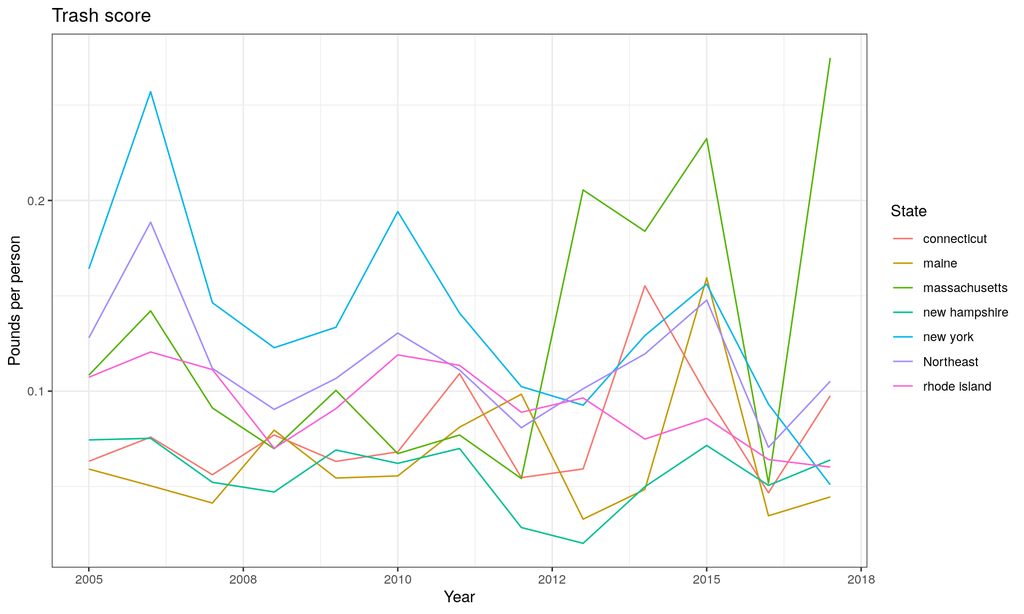

```r
trash_resc <- ne_data %>%
  mutate(score = pounds_per_person/ref)

#save for use in dashboard
write.csv(trash_resc, "data/trash.csv")

ggplot(trash_resc, aes(x = year, y = score, color = state)) +
  geom_line() +
  theme_bw() +
  labs(x = "Year",
       y = "Pounds per person",
       title = "Trash score",
       color = "State")
```

## Save layer for toolbox

I need to attach region ID’s to each row. All states except Massachusetts match up to a region. Since this data is not broken down to a coarser resolution, both MA regions will get the same score. I also add the offshore regions 1:4 with NA values for the toolbox to run.

```r
rgns <- rgn_data %>%
  data.frame() %>%
  mutate(state = tolower(state))

trash_resc %>%
  left_join(rgns) %>%
  mutate(rgn_name = ifelse(state == "Northeast", "Northeast", rgn_name),
         rgn_id   = ifelse(state == "Northeast", 12, rgn_id),
         score = 1-score) %>% #inverse because low trash is a good score
  select(year, rgn_id, score) %>%
  complete(rgn_id = 1:12, #this adds in regions 1-4 with NA values for pounds_pp
           year) %>%
  write.csv(file.path(dir_calc, "layers/cw_trash.csv"))
```

```r
trash_prs <- trash_resc %>%
  left_join(rgns) %>%
  mutate(rgn_name = ifelse(state == "Northeast", "Northeast", rgn_name),
         rgn_id   = ifelse(state == "Northeast", 12, rgn_id)) %>%
  select(year, rgn_id, score) %>%
  complete(rgn_id = 1:12, #this adds in regions 1-4 with NA values for pounds_pp
           year) %>%
  write.csv(file.path(dir_calc, "layers/prs_trash.csv"))
```